# Biomedical Statistics Homework 06

- Show All Code
- Hide All Code
- View Source

Author

Zipeng YE (CEBSIT, CAS)

# 1 Question 1

**数据准备与预处理**： 首先加载内置的 `PlantGrowth` 数据集，只提取 `trt1` 和 `trt2` 两个处理组的数据。

```r
# 加载数据集
data("PlantGrowth")

# 提取 trt1 和 trt2 的子集
trt_data <- subset(PlantGrowth, group %in% c("trt1", "trt2"))

# 为了消除不再使用的 'ctrl' 因子水平带来的潜在干扰，我们重新定义因子
trt_data$group <- factor(trt_data$group)

# 检查子集是否提取成功
table(trt_data$group)
```

```
trt1 trt2
  10   10
```

## 1.1 统计假设检验

在进行均值比较之前，先验证独立样本 t 检验的两个核心前提：正态性和方差齐性。

### 1.1.1 正态性检验（Shapiro-Wilk Test）

分别对 `trt1` 和 `trt2` 组的数据进行正态性检验。

```r
# 分离数据以便检验
w_trt1 <- trt_data$weight[trt_data$group == "trt1"]
w_trt2 <- trt_data$weight[trt_data$group == "trt2"]

# 执行 Shapiro-Wilk 检验
(shapiro_trt1 <- shapiro.test(w_trt1))
```

```
    Shapiro-Wilk normality test

data:  w_trt1
W = 0.93041, p-value = 0.4519
```

```r
(shapiro_trt2 <- shapiro.test(w_trt2))
```

```
    Shapiro-Wilk normality test

data:  w_trt2
W = 0.94101, p-value = 0.5643
```

**结论**：`tr1` 和 `trt2` 组的 p 值分别为 0.451944 和 0.5642519，都大于 0.05，认为数据满足正态分布的假设。

### 1.1.2 方差齐性检验（F-test）

检验两组植物重量的方差是否相等。

```r
# 执行方差齐性检验
(var_test_res <- var.test(weight ~ group, data = trt_data))
```

```
    F test to compare two variances

data:  weight by group
F = 3.216, num df = 9, denom df = 9, p-value = 0.0968
alternative hypothesis: true ratio of variances is not equal to 1
95 percent confidence interval:
  0.7988084 12.9475894
sample estimates:
ratio of variances
          3.215998
```

**结论**：方差齐性检验的 p 值为 0.0968035，大于 0.05，认为两组方差齐。

## 1.2 均值差异分析

由于满足独立样本 t 检验的前提条件，故使用**标准的独立样本 t 检验**。

- **$H_0$**: `trt1` 和 `trt2` 肥料处理下的植物平均重量没有显著差异 ($\mu_{trt1} = \mu_{trt2}$)。
- **$H_1$**: 两种处理下的平均重量存在显著差异 ($\mu_{trt1} \neq \mu_{trt2}$)。

```r
# 执行独立样本 t 检验（var.equal = TRUE）
(t_test_res <- t.test(weight ~ group, data = trt_data, var.equal = TRUE))
```

```
    Two Sample t-test

data:  weight by group
t = -3.0101, df = 18, p-value = 0.007518
alternative hypothesis: true difference in means between group trt1 and group trt2 is not equal to 0
95 percent confidence interval:
 -1.4687336 -0.2612664
sample estimates:
mean in group trt1 mean in group trt2
             4.661              5.526
```

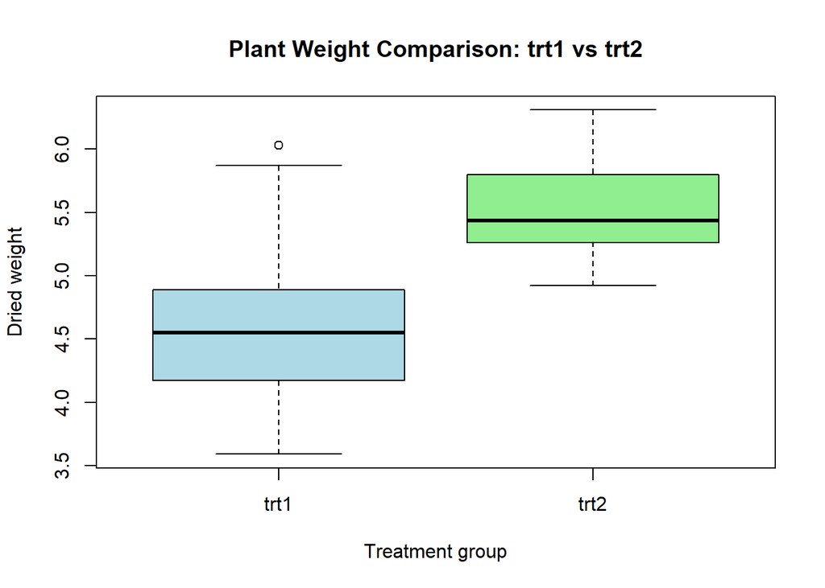

```r
# 数据可视化：绘制箱线图（可选）
boxplot(weight ~ group, data = trt_data,
        col = c("lightblue", "lightgreen"),
        main = "Plant Weight Comparison: trt1 vs trt2",
        ylab = "Dried weight",
        xlab = "Treatment group")
```

**结论**：t 检验的 p 值为 0.0075184，小于 0.01，拒绝 $H_0$，认为 `trt1` 和 `trt2` 处理下的植物平均重量存在极显著差异。

# 2 Question 2

**数据准备与预处理**： 在 ANOVA 中，确保分组变量被 R 识别为 factor。

```r
# 读取数据
data <- read.csv("data/raw/homework6-Q2.csv",
                 stringsAsFactors = TRUE)

# 确保 drug 和 time 属于分类因子
data$drug <- as.factor(data$drug)
data$time <- as.factor(data$time)

# 简单查看数据结构
str(data)
```

```
'data.frame':   24 obs. of  9 variables:
 $ X        : int  1 2 3 4 5 6 7 8 9 10 ...
 $ SampleID : Factor w/ 24 levels "S1","S10","S11",..: 1 12 18 19 20 21 22 23 24 2 ...
 $ Batch    : Factor w/ 2 levels "Batch1","Batch2": 1 1 1 1 1 1 1 1 1 1 ...
 $ CellLine : Factor w/ 1 level "A549": 1 1 1 1 1 1 1 1 1 1 ...
 $ Plate    : Factor w/ 2 levels "Plate1","Plate2": 1 1 1 1 1 1 1 1 1 1 ...
 $ Well     : Factor w/ 24 levels "A1","A2","A3",..: 1 2 3 4 5 6 7 8 9 10 ...
 $ drug     : Factor w/ 4 levels "Control","DrugA",..: 1 1 1 1 1 1 2 2 2 2 ...
 $ time     : Factor w/ 2 levels "24h","48h": 1 1 1 2 2 2 1 1 1 2 ...
 $ viability: num  93 96 102 108 99 100 82 74 79 82 ...
```

## 2.1 单因素方差分析（One-way ANOVA）

在此步骤中，暂不考虑治疗时间，仅评估不同药物处理组（整体均值）之间是否存在显著差异。

```r
# 1. 拟合单因素方差分析模型
model_1way <- aov(viability ~ drug, data = data)

# 打印 ANOVA 摘要
cat("--- One-way ANOVA 结果 ---\n")
```

```
--- One-way ANOVA 结果 ---
```

```r
summary(model_1way)
```

```
            Df Sum Sq Mean Sq F value   Pr(>F)
drug         3 2505.0     835   25.33 5.13e-07 ***
Residuals   20  659.3      33
---
Signif. codes:  0 '***' 0.001 '**' 0.01 '*' 0.05 '.' 0.1 ' ' 1
```

```
--- Tukey HSD 事后检验结果 ---
  Tukey multiple comparisons of means
    95% family-wise confidence level

Fit: aov(formula = viability ~ drug, data = data)

$drug
                    diff        lwr         upr     p adj
DrugA-Control -18.000000 -27.277886  -8.7221142 0.0001408
DrugB-Control -27.983333 -37.261219 -18.7054475 0.0000003
DrugC-Control -10.816667 -20.094552  -1.5387809 0.0187362
DrugB-DrugA    -9.983333 -19.261219  -0.7054475 0.0321251
DrugC-DrugA     7.183333  -2.094552  16.4612191 0.1667520
DrugC-DrugB    17.166667   7.888781  26.4445525 0.0002475
```

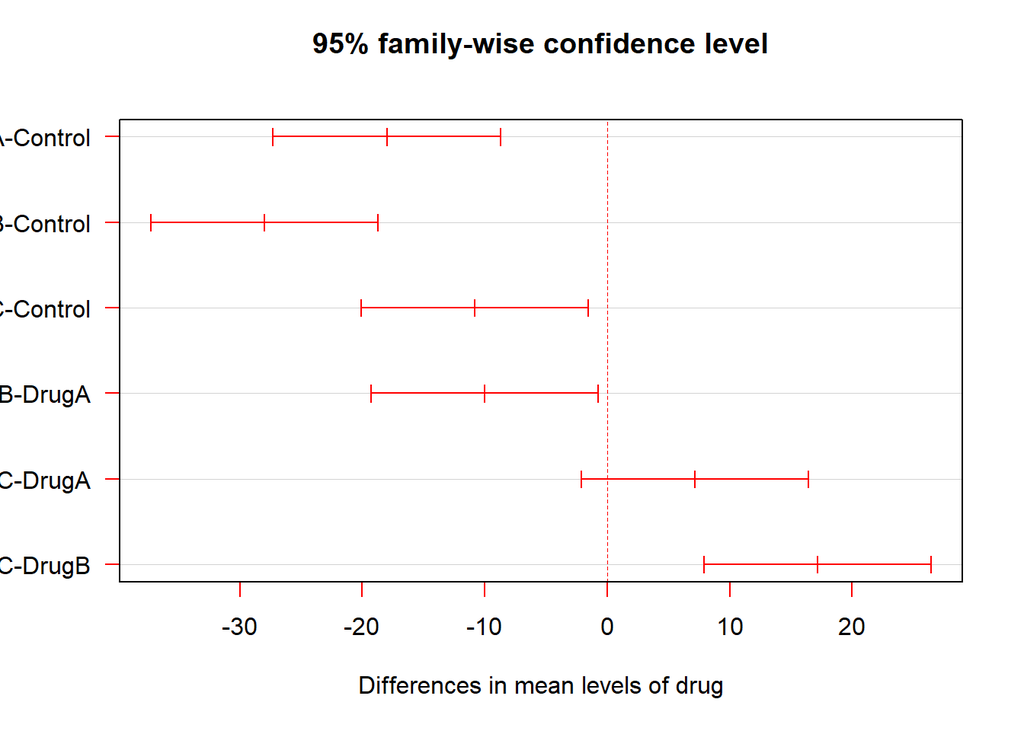

```r
# 2. 如果显著，进行 Tukey's HSD 事后多重比较
# 根据 summary()，如果 Pr(>F) < 0.05，则执行以下步骤
if (summary(model_1way)[[1]][["Pr(>F)"]][1] < 0.05) {
  tukey_res <- TukeyHSD(model_1way)
  cat("\n--- Tukey HSD 事后检验结果 ---\n")
  print(tukey_res)

  # 简单可视化（可选）
  plot(tukey_res, las = 1, col = "red")
}
```

**结论**：

- **整体检验**：`drug` 组间的 p-value 为 5.1337407^{-7}，小于 0.01，说明不同药物对细胞活力的影响存在极其显著的统计学差异。
- **事后检验**：通过对比 `p adj` 列可以发现，与 Control 相比，Drug A、Drug B、Drug C 均显著降低了细胞活力（$p < 0.05$），表明三种药物均具有抗肿瘤增殖活性。此外，Drug B 的抑制效果最强，与 Drug A 和 Drug C 之间的差异也达到了统计学显著水平（$p < 0.05$）。

## 2.2 双因素方差分析（Two-way ANOVA）

### 2.2.1 执行 two-way ANOVA

现在同时引入 `drug` 和 `time`，构建包含交互作用项的双因素模型，因为药物的起效程度往往依赖于作用时间。

```r
# 拟合包含交互作用的双因素方差分析模型
model_2way <- aov(viability ~ drug * time, data = data)

# 打印 ANOVA 摘要
cat("--- Two-way ANOVA 结果 ---\n")
```

```
--- Two-way ANOVA 结果 ---
```

```r
summary(model_2way)
```

```
            Df Sum Sq Mean Sq F value   Pr(>F)
drug         3 2505.0   835.0  48.162 3.11e-08 ***
time         1   10.7    10.7   0.615  0.44428
drug:time    3  371.2   123.7   7.137  0.00294 **
Residuals   16  277.4    17.3
---
Signif. codes:  0 '***' 0.001 '**' 0.01 '*' 0.05 '.' 0.1 ' ' 1
```

**结论**：

- `drug` 主效应极显著 ($p < 0.01$)。
- `drug:time` 交互效应极显著 ($p < 0.01$)。
- `time` 主效应不显著 ($p > 0.05$)。

这表明药物的抑制效果不仅取决于药物类型，还受到治疗时间的显著影响，存在明显的时间依赖性。时间主效应不显著可能是因为不同药物在不同时间点的效应方向相反（如对照组在 48h 增殖，而 Drug B 在 48h 抑制），导致整体时间效应被抵消。

### 2.2.2 执行基于 BH 校正的配对 t 检验

使用 `interaction(drug, time)` 将两个因子融合成 $4 \times 2 = 8$ 个独立的分组，然后进行两两对比，并使用 Benjamini-Hochberg（BH）方法控制假阳性。

```r
# 使用 pairwise.t.test 进行多重比较
# interaction() 将生成类似 "Control.24h", "DrugA.48h" 的组合标签
posthoc_interaction <- pairwise.t.test(
  x = data$viability,
  g = interaction(data$drug, data$time),
  p.adjust.method = "BH"
)

cat("\n--- 所有 Drug-Time 组合的 Pairwise t-test (BH 校正) ---\n")
```

```
--- 所有 Drug-Time 组合的 Pairwise t-test (BH 校正) ---
```

```r
print(posthoc_interaction)
```

```
    Pairwise comparisons using t tests with pooled SD

data:  data$viability and interaction(data$drug, data$time)

            Control.24h DrugA.24h DrugB.24h DrugC.24h Control.48h DrugA.48h
DrugA.24h   0.00015     -         -         -         -           -
DrugB.24h   0.00014     0.92311   -         -         -           -
DrugC.24h   0.12523     0.00325   0.00308   -         -           -
Control.48h 0.15262     1.5e-05   1.5e-05   0.00785   -           -
DrugA.48h   0.00487     0.08595   0.07488   0.10584   0.00030     -
DrugB.48h   1.0e-06     0.00325   0.00351   1.0e-05   2.4e-07     0.00011
DrugC.48h   0.01096     0.04032   0.03488   0.20012   0.00067     0.68959
            DrugB.48h
DrugA.24h   -
DrugB.24h   -
DrugC.24h   -
Control.48h -
DrugA.48h   -
DrugB.48h   -
DrugC.48h   5.8e-05

P value adjustment method: BH
```

### 2.2.3 数据可视化验证（可选）

绘制带有误差线的柱状图或交互作用图，能够最直观地展示为什么需要分析它们的组合效应。

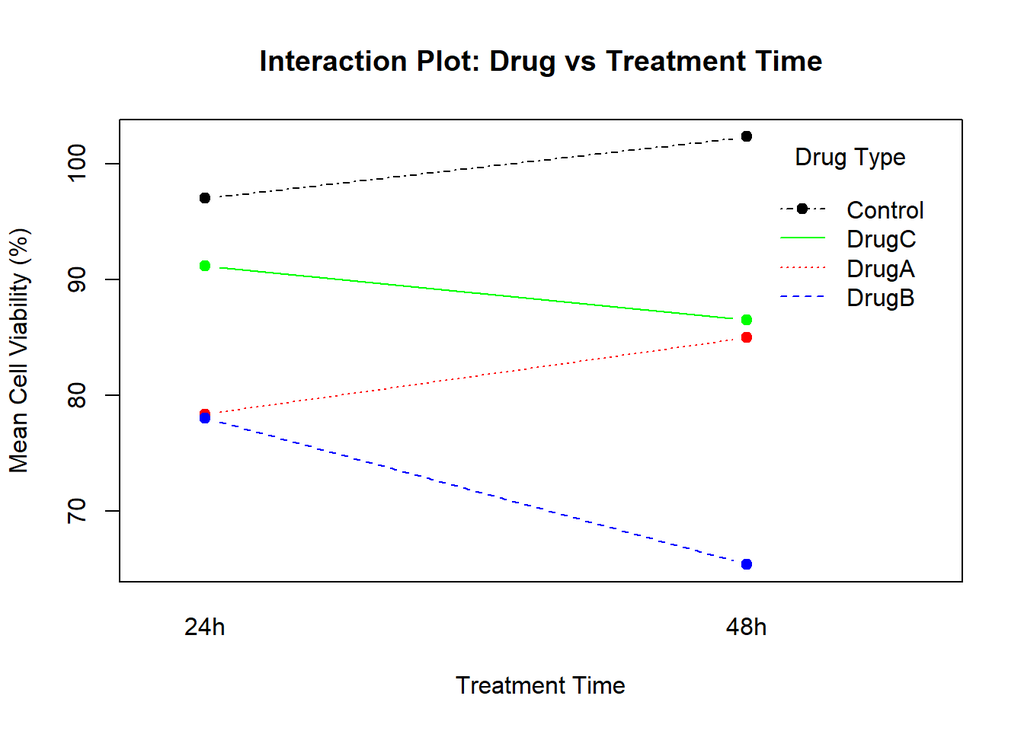

```r
# 绘制交互作用折线图
interaction.plot(
  x.factor = data$time,
  trace.factor = data$drug,
  response = data$viability,
  type = "b", pch = 19, col = c("black", "red", "blue", "green"),
  xlab = "Treatment Time", ylab = "Mean Cell Viability (%)",
  trace.label = "Drug Type",
  main = "Interaction Plot: Drug vs Treatment Time"
)
```

# 3 Question 3

## 3.1 散点图矩阵与完整多元线性回归

### 3.1.1 数据可视化与模型拟合

探索多个连续变量之间的关系时，散点图矩阵能够直观展示变量间的共线性和初步的线性相关趋势。随后，使用普通最小二乘法拟合多元线性回归。

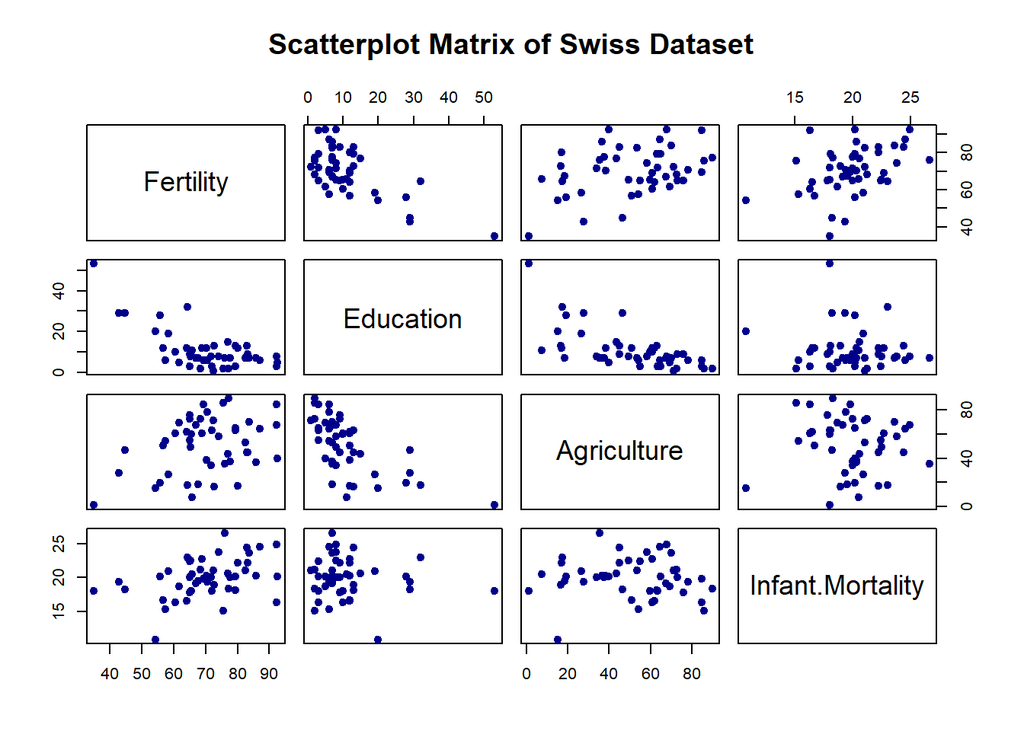

```r
# 加载必要的 R 包
library(glue) # 用于字符串格式化输出

# 1. 加载数据集
data(swiss)

# 2. 绘制散点图矩阵
pairs(~ Fertility + Education + Agriculture + Infant.Mortality,
      data = swiss,
      main = "Scatterplot Matrix of Swiss Dataset",
      pch = 19, col = "darkblue")
```

```r
# 3. 构建完整多元线性回归模型 (Full Model)
model_full <- lm(Fertility ~ Education + Agriculture + Infant.Mortality,
                 data = swiss)

# 输出模型摘要
summary(model_full)
```

```
Call:
lm(formula = Fertility ~ Education + Agriculture + Infant.Mortality,
    data = swiss)

Residuals:
    Min      1Q  Median      3Q     Max
-15.533  -6.310  -1.517   6.032  21.547

Coefficients:
                 Estimate Std. Error t value Pr(>|t|)
(Intercept)      51.10129   10.99484   4.648 3.18e-05 ***
Education        -0.85697    0.17258  -4.966 1.13e-05 ***
Agriculture      -0.02618    0.07284  -0.359  0.72107
Infant.Mortality  1.49308    0.43880   3.403  0.00145 **
---
Signif. codes:  0 '***' 0.001 '**' 0.01 '*' 0.05 '.' 0.1 ' ' 1

Residual standard error: 8.511 on 43 degrees of freedom
Multiple R-squared:  0.5661,    Adjusted R-squared:  0.5358
F-statistic:  18.7 on 3 and 43 DF,  p-value: 6.517e-08
```

### 3.1.2 模型结果解析

线性回归评估的是在**控制其他变量不变**的情况下，单一自变量对因变量的独立贡献。

- **回归系数（$\beta$）**：表示自变量每改变一个单位，`Fertility` 的预期变化量。这里，`Education` 的系数为负，说明教育水平越高，生育率越低；`Agriculture` 的系数为负，说明农业就业比例越高，生育率越低；`Infant.Mortality` 的系数为正，说明婴儿死亡率越高，生育率越高。
- **显著性（p-value）**：如果在 $\alpha = 0.05$ 阈值下，$p < 0.05$，说明该变量对因变量有统计学意义上的独立预测价值。这里，`Education` 和 `Infant.Mortality` 的 p 值都小于 0.01，表明它们是生育率的重要预测因子；而 `Agriculture` 的 p 值为大于 0.05，说明其独立贡献不显著。
- **模型整体评估（F-test）**：其 `p-value` 表示这三个变量作为一个整体是否能够显著解释生育率的变异。这里的 p 值极小，说明整体模型是显著的。

## 3.2 模型降维与比较

在多元回归中，包含不显著的变量会引入噪声，增加方差。通常通过剔除 $p > 0.05$ 的变量来获得更简约的模型。由于这里 `Agriculture` 的 p 值不显著，我们将其剔除，构建简化模型（Reduced Model），并比较两个模型的 $R^2$、Adjusted $R^2$ 以及使用 ANOVA 检验两者的显著性差异。

```r
# 提取模型系数和 p-value，确定需要剔除的变量
# 在本数据集的这组变量中，Agriculture 是不显著的
model_reduced <- lm(Fertility ~ Education + Infant.Mortality, data = swiss)
summary(model_reduced)
```

```
Call:
lm(formula = Fertility ~ Education + Infant.Mortality, data = swiss)

Residuals:
     Min       1Q   Median       3Q      Max
-15.3906  -6.0088  -0.9624   5.8808  21.0736

Coefficients:
                 Estimate Std. Error t value Pr(>|t|)
(Intercept)       48.8213     8.8904   5.491 1.88e-06 ***
Education         -0.8167     0.1298  -6.289 1.27e-07 ***
Infant.Mortality   1.5187     0.4287   3.543 0.000951 ***
---
Signif. codes:  0 '***' 0.001 '**' 0.01 '*' 0.05 '.' 0.1 ' ' 1

Residual standard error: 8.426 on 44 degrees of freedom
Multiple R-squared:  0.5648,    Adjusted R-squared:  0.545
F-statistic: 28.55 on 2 and 44 DF,  p-value: 1.126e-08
```

```r
# 比较 R-squared 和 Adjusted R-squared
r2_full <- summary(model_full)$r.squared
adj_r2_full <- summary(model_full)$adj.r.squared

r2_reduced <- summary(model_reduced)$r.squared
adj_r2_reduced <- summary(model_reduced)$adj.r.squared

cat(glue("完整模型 R-squared: {r2_full},
         Adjusted R-squared: {adj_r2_full}\n"))
```

```
完整模型 R-squared: 0.566083296615593,
Adjusted R-squared: 0.535810038239937
```

```r
cat(glue("简化模型 R-squared: {r2_reduced},
         Adjusted R-squared: {adj_r2_reduced}\n"))
```

```
简化模型 R-squared: 0.564780008270049,
Adjusted R-squared: 0.544997281373233
```

```r
# 使用 ANOVA 检验嵌套模型间的显著性差异
anova(model_reduced, model_full)
```

```
Analysis of Variance Table

Model 1: Fertility ~ Education + Infant.Mortality
Model 2: Fertility ~ Education + Agriculture + Infant.Mortality
  Res.Df    RSS Df Sum of Sq      F Pr(>F)
1     44 3124.0
2     43 3114.6  1    9.3549 0.1292 0.7211
```

### 3.2.1 模型结果解析

- **R-squared** vs **Adjusted R-squared**：表示模型解释了因变量变异的百分比。简化模型的 R-squared 略有下降，但 Adjusted R-squared 却略有提升，说明剔除 `Agriculture` 后模型的解释力并未降低，反而更简洁。
- **ANOVA 检验**：p 值大于 0.05，说明简化模型与完整模型之间没有显著差异，进一步支持剔除 `Agriculture` 的合理性。

## 3.3 逻辑回归与模型差异解析

将连续的 `Fertility` 强制转换为二元分类变量，并拟合广义线性模型（GLM）。

```r
# 1. 设定阈值，构建二分类目标变量
median_fertility <- median(swiss$Fertility)
swiss$high_fertility <- ifelse(swiss$Fertility > median_fertility, 1, 0)

# 2. 构建逻辑回归模型
model_logit <- glm(high_fertility ~ Education + Agriculture + Infant.Mortality,
                   data = swiss,
                   family = binomial)

# 输出模型摘要
summary(model_logit)
```

```
Call:
glm(formula = high_fertility ~ Education + Agriculture + Infant.Mortality,
    family = binomial, data = swiss)

Coefficients:
                  Estimate Std. Error z value Pr(>|z|)
(Intercept)      -2.963970   3.431031  -0.864   0.3877
Education        -0.188042   0.089253  -2.107   0.0351 *
Agriculture      -0.009601   0.019796  -0.485   0.6277
Infant.Mortality  0.260078   0.141399   1.839   0.0659 .
---
Signif. codes:  0 '***' 0.001 '**' 0.01 '*' 0.05 '.' 0.1 ' ' 1

(Dispersion parameter for binomial family taken to be 1)

    Null deviance: 65.135  on 46  degrees of freedom
Residual deviance: 50.371  on 43  degrees of freedom
AIC: 58.371

Number of Fisher Scoring iterations: 6
```

### 3.3.1 为什么同一组自变量在两个模型中的效应量与显著性存在差异？

这种差异是由这两种统计模型的**数学架构**与**数据信息量**本质不同所导致的：

1. **量纲与效应量解释不同**：
- **线性回归**建模的是连续响应变量的均值 $\mathbb{E}(Y)$。系数 $\beta$ 表示自变量单位增加所导致的 `Fertility` **绝对数值**的线性增减。
- **逻辑回归**建模的是对数几率 $\ln(\frac{p}{1-p})$。系数 $\beta$ 表示自变量单位增加所导致的“高于中位数生育率”的**对数发生比（Log-odds）** 的变化。两者在数学空间上不可通约。
2. **人为二值化导致严重的信息丢失**： 将连续变量离散化为 0 和 1 是一种激进的降维。例如，原本生育率为 $80$ 和 $90$ 的地区存在显著差异，但在二值化后都被平等地视为 $1$。这极大地抹平了组内的方差分布。
3. **统计功效下降**： 由于上述的信息丢失，逻辑回归的拟合所能利用的数据颗粒度变粗，模型的残差和不确定性上升。这通常会导致标准误变大，从而拉低了检验统计量 (Z-value)，使得原本在线性模型中显著的变量在逻辑模型中变得不显著（即假阴性风险增加）。这也是为什么在科研设计中，通常不建议将能够连续测量的指标人为转化为二值指标的原因。

# 4 Question 4

## 4.1 主成分分析（PCA）与方差解释率

```r
# 1. 加载数据
data("USArrests")

# 2. 执行 PCA (必须标准化数据: scale. = TRUE)
pca_res <- prcomp(USArrests, scale. = TRUE)

# 3. 计算方差解释率
# 标准差的平方即为方差（特征值）
var_explained <- pca_res$sdev^2 / sum(pca_res$sdev^2)
cum_var_explained <- cumsum(var_explained) # "cumsum" 表示累积和

# 输出解释率
cat("各主成分方差解释率 (Proportion of Variance):\n")
```

```
各主成分方差解释率 (Proportion of Variance):
```

```r
print(round(var_explained, 4))
```

```
[1] 0.6201 0.2474 0.0891 0.0434
```

```r
cat("累积方差解释率 (Cumulative Variance):\n")
```

```
累积方差解释率 (Cumulative Variance):
```

```r
print(round(cum_var_explained, 4))
```

```
[1] 0.6201 0.8675 0.9566 1.0000
```

## 4.2 PCA Biplot 可视化与成分解释

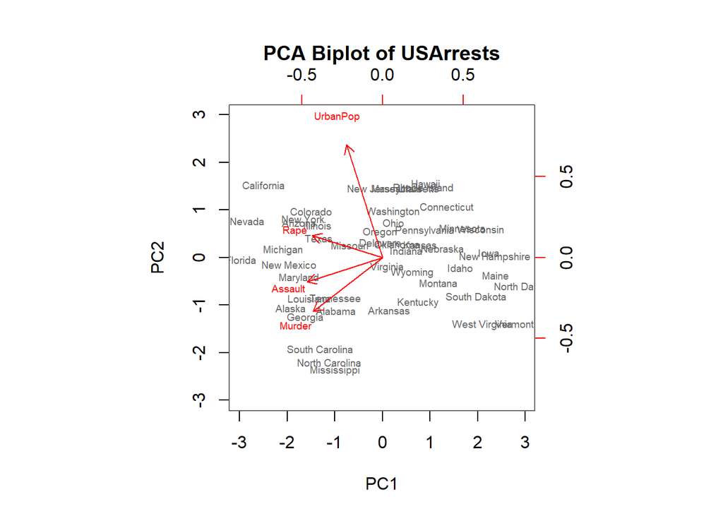

```r
# 绘制 Biplot
biplot(pca_res, scale = 0, cex = 0.6,
       main = "PCA Biplot of USArrests",
       col = c("grey40", "red"))
```

**图像解析与物理意义：**

1. **变量相关性（箭头的方向）**： `Murder`（谋杀）、`Assault`（袭击）和 `Rape`（强奸）这三个箭头的方向非常接近，这表明这三种暴力犯罪指标在各州之间具有**强烈的正相关性**。
2. **PC 平面的贡献度（箭头的长度）**： `Murder`（谋杀）、`Assault`（袭击）、`Rape`（强奸）和 `UrbanPop`（城市人口比例）四个变量的箭头长度都比较长，说明它们在 PC1-PC2 平面上都有很强的贡献。
3. **主成分的物理意义解释**：
- **PC1**：三个暴力犯罪指标（`Murder`, `Assault`, `Rape`）在横轴上的投影（Loading）都非常大且为同一方向。因此，PC1 可以被解释为“总体严重暴力犯罪指数”。
- **PC2**：`UrbanPop`（城市人口比例）的箭头几乎垂直指向 PC2 的轴线，且与其他犯罪指标近乎正交（独立）。因此，PC2 可以被解释为“城市化程度”。

## 4.3 K-means 聚类（基于 PC1 和 PC2）

在真实的生信分析中，我们通常会在降维后的主成分空间（而非原始高维空间）进行聚类，以达到去噪的目的。

```r
# 1. 提取 PC1 和 PC2 的得分
pca_scores <- as.data.frame(pca_res$x[, 1:2])

# 2. 执行 K-means 聚类（设置 K=3）
# 设置随机种子保证聚类结果可重复
set.seed(42)
kmeans_res <- kmeans(pca_scores, centers = 3, nstart = 25)

# 将聚类结果合并回数据框
pca_scores$Cluster <- as.factor(kmeans_res$cluster)

# 3. 输出每个州的聚类归属
cat("States Cluster Assignment:\n")
```

```
States Cluster Assignment:
```

```r
print(kmeans_res$cluster)
```

```
       Alabama         Alaska        Arizona       Arkansas     California
             3              3              3              2              3
      Colorado    Connecticut       Delaware        Florida        Georgia
             3              2              2              3              3
        Hawaii          Idaho       Illinois        Indiana           Iowa
             2              1              3              2              1
        Kansas       Kentucky      Louisiana          Maine       Maryland
             2              1              3              1              3
 Massachusetts       Michigan      Minnesota    Mississippi       Missouri
             2              3              1              3              3
       Montana       Nebraska         Nevada  New Hampshire     New Jersey
             1              2              3              1              2
    New Mexico       New York North Carolina   North Dakota           Ohio
             3              3              3              1              2
      Oklahoma         Oregon   Pennsylvania   Rhode Island South Carolina
             2              2              2              2              3
  South Dakota      Tennessee          Texas           Utah        Vermont
             1              3              3              2              1
      Virginia     Washington  West Virginia      Wisconsin        Wyoming
             2              2              1              1              2
```

**聚类特征简述**：

- **Cluster 1（低犯罪率组）**：聚集在 PC1 暴力犯罪极端反方向的州，特征为社会治安良好。
- **Cluster 2（中犯罪率组）**：位于 PC1 中部，特征为犯罪率中等。
- **Cluster 3（高犯罪率组）**：聚集在 PC1 暴力犯罪极端方向的州，特征为总体治安恶劣。

## 4.4 降维空间中的聚类可视化与工作流评价

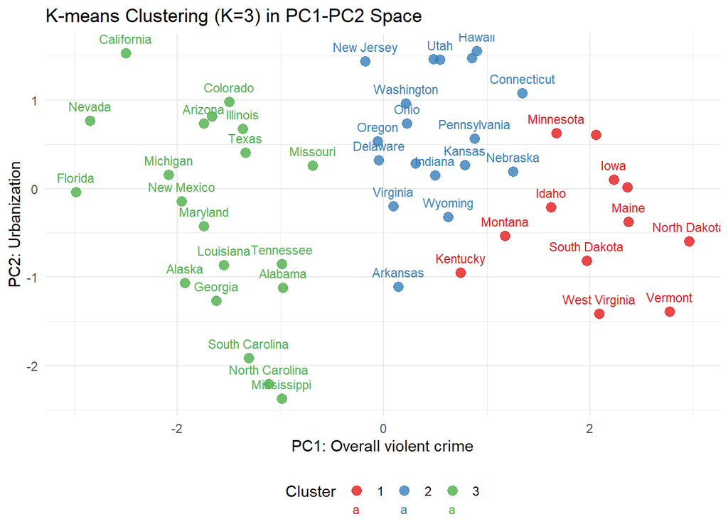

```r
# 加载 ggplot2 进行高级可视化
library(ggplot2)

# 绘制 PCA 散点图并根据 K-means 聚类结果着色
ggplot(
  pca_scores,
  aes(x = PC1, y = PC2, color = Cluster, label = rownames(pca_scores))
) +
  geom_point(size = 3, alpha = 0.8) +
  geom_text(vjust = -1, size = 3, check_overlap = TRUE) +
  scale_color_brewer(palette = "Set1") +
  theme_minimal() +
  labs(title = "K-means Clustering (K=3) in PC1-PC2 Space",
       x = "PC1: Overall violent crime",
       y = "PC2: Urbanization") +
  theme(legend.position = "bottom")
```

**图像评价**： 在 PC1-PC2 平面中，这 3 个 clusters 呈现出清晰的分离、几乎没有重叠。这是因为 K-means 算法倾向于寻找空间中紧凑的凸形球体，而我们在用于聚类的正是用来画图的这两个维度。

**“PCA 降维 + K-means 聚类”工作流评价**：

1. **优势**：
   - **去噪**：PCA 过滤掉了原始数据中方差较小的“长尾”噪音，使得 K-means 能够在最反映本质差异的特征空间中进行更稳健的距离计算。
   - **可视化**：将高维数据压缩至二维或三维，人类可以直观地通过肉眼验证聚类算法是否切分合理。
   - **计算效率**：在超高维数据（如上万个基因的 RNA-seq）中，先降维能极大加速聚类计算，突破维度灾难。
2. **局限性**：
   - **线性限制**：PCA 只能捕捉线性相关。如果数据流形是复杂的非线性结构，PCA 降维后会强行破坏局部结构，导致 K-means 分错类。此时需要 UMAP/t-SNE 进行非线性降维。
   - **信息丢失**：只保留前几个 PC 必然会丢失部分信息。如果某些关键生物学差异隐藏在 PC3 或 PC4 中，这种降维聚类会彻底掩盖真相。

# 5 Question 5

## 5.1 单细胞 RNA-seq 标准分析流程

在单细胞 RNA-seq 数据分析中，Seurat 是最流行的 R 包之一。它提供了从数据预处理、质控过滤、标准化、降维、聚类到差异表达分析的一站式解决方案。以下是题目给出的典型 Seurat 工作流程：

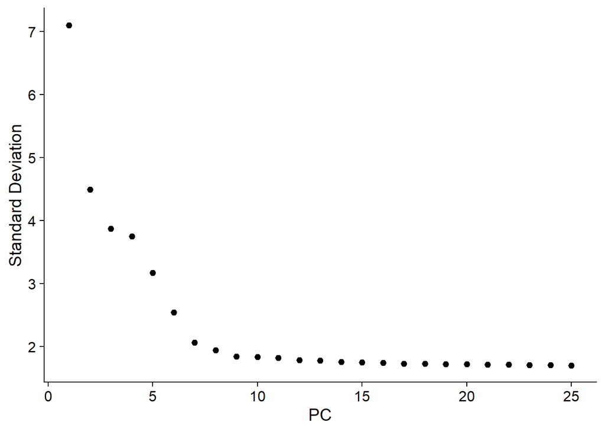

```r
# 加载必要的 R 包
library(Seurat)
library(dplyr)
library(patchwork)

# 1. 加载 10X 数据并创建 Seurat 对象
pbmc.data <- Read10X(data.dir = 'data/raw/filtered_gene_bc_matrices/hg19/')
pbmc <- CreateSeuratObject(
  counts = pbmc.data,
  project = "pbmc3k",
  min.cells = 3,     # 过滤掉在少于 3 个细胞中表达的基因
  min.features = 200 # 过滤掉表达少于 200 个基因的细胞
)

# 2. 质控与过滤
pbmc[['percent.mt']] <- PercentageFeatureSet(pbmc, pattern = "^MT-") # 计算线粒体基因占比
pbmc <- subset(
  pbmc,
  subset = nFeature_RNA > 200 & # 过滤掉表达基因数量极少的“空液滴”
    nFeature_RNA < 2500 &       # 过滤掉表达基因数量极高的“双胞/多胞”
    percent.mt < 5              # 过滤掉线粒体基因表达比例过高的细胞
)

# 3. 标准化
pbmc <- NormalizeData(
  pbmc,
  normalization.method = "LogNormalize", # 采用总计数归一化并进行 log 转换
  scale.factor = 10000                   # 将每个细胞的总计数缩放到 10000，类似于 TPM/CPM 的概念
)

# 4. 寻找高变基因并缩放
pbmc <- FindVariableFeatures(
  pbmc,
  selection.method = "vst", # 使用方差稳定变换方法寻找高变基因
  nfeatures = 2000          # 选择表达量变化最大的 2000 个基因作为后续分析的特征
)
all.genes <- rownames(pbmc) # 获取所有基因的名称
pbmc <- ScaleData(pbmc, features = all.genes) # 对所有基因进行缩放，使其均值为 0，方差为 1

# 5. 线性降维（PCA）
pbmc <- RunPCA(
  pbmc,
  features = VariableFeatures(object = pbmc) # 仅使用高变基因进行 PCA 降维
)
ElbowPlot(pbmc, ndims = 25) # 绘制 Elbow Plot 以帮助确定保留多少个主成分（PCs）
```

```r
# 6. 非线性聚类与 UMAP 降维
pbmc <- FindNeighbors(pbmc, dims = 1:20) # 基于前 20 个 PCs 构建 KNN 图
pbmc <- FindClusters(
  pbmc,
  resolution = 0.5
) # 使用 Louvain 算法进行社区检测，resolution 参数控制聚类的细粒度
```

```
Modularity Optimizer version 1.3.0 by Ludo Waltman and Nees Jan van Eck

Number of nodes: 2638
Number of edges: 120087

Running Louvain algorithm...
Maximum modularity in 10 random starts: 0.8659
Number of communities: 9
Elapsed time: 0 seconds
```

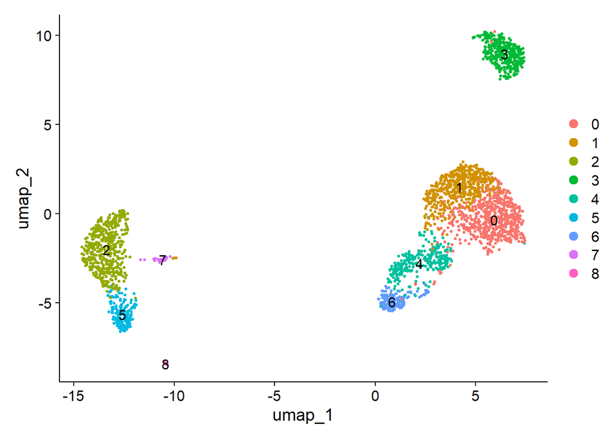

```r
pbmc <- RunUMAP(pbmc, dims = 1:20) # 在前 20 个 PCs 上运行 UMAP 进行非线性降维
DimPlot(pbmc, reduction = "umap", label = TRUE) # 绘制 UMAP 图并标注聚类结果
```

```r
# 7. 寻找 Marker 基因
cluster_markers <- FindAllMarkers(
  pbmc,
  only.pos = TRUE,       # 仅返回在某个 cluster 中上调的基因
  min.pct = 0.25,        # 仅考虑在至少 25% 的细胞中表达的基因
  logfc.threshold = 0.25 # 仅考虑 log2 fold change 大于 0.25 的基因
)
top10 <- cluster_markers %>%
  group_by(cluster) %>%          # 按 cluster 分组
  top_n(n = 10, wt = avg_log2FC) # 每个 cluster 选择 log2 fold change 最大的前 10 个基因
head(top10)
```

```
# A tibble: 6 × 7
# Groups:   cluster [1]
  p_val avg_log2FC pct.1 pct.2 p_val_adj cluster gene
  <dbl>      <dbl> <dbl> <dbl>     <dbl> <fct>   <chr>
1     0       1.67 0.75  0.288         0 0       IL7R
2     0       1.61 0.607 0.223         0 0       CD2
3     0       2.45 0.412 0.086         0 0       AQP3
4     0       1.80 0.392 0.101         0 0       TRAT1
5     0       1.73 0.349 0.121         0 0       TRADD
6     0       2.25 0.262 0.052         0 0       CD40LG
```

*（实际上，2025 年本人在神经所孙怡迪课题组轮转期间已充分实践过该流程，但因时间久远且本人已不再从事相关研究，故细节已有所遗忘。）*

## 5.2 核心原理问题解答

### 5.2.1 问题 1: barcodes, genes, matrix 这三个文件分别代表什么？

在 10X Genomics 平台的输出格式中（也是 `Read10X` 函数默认读取的格式），这三个文件共同构成了一个稀疏矩阵（Sparse Matrix）：

1. **`barcodes.tsv`（列名）**：包含了被测序的每一个独立“细胞”的条形码序列（如 `AAACATACAACCAC-1`）。在矩阵中代表所有的“列”。
2. **`genes.tsv`（行名）**：包含了所有检测到的基因信息（包括 Ensembl ID 和对应的基因名称）。在矩阵中代表所有的“行”。
3. **`matrix.mtx`（数值）**：这是一个稀疏坐标格式的数据文件。它只记录非零的表达量，其结构通常为三列 `(行索引，列索引，UMI counts 计数)`。这种设计极大地节省了硬盘空间，因为单细胞数据通常极其稀疏（90% 以上的数值为 0）。

### 5.2.2 问题 2: 质控过滤条件的目的是什么？还有其他条件吗？

**代码中过滤条件的目的**：

- `nFeature_RNA > 200`：过滤掉表达基因数量极少的“空液滴”，这些通常是没有包裹到完整细胞的背景噪音。
- `nFeature_RNA < 2500`：过滤掉表达基因数量极高的“双胞/多胞”，即一个液滴中意外包裹了两个或多个细胞，导致基因种类异常增多。
- `percent.mt < 5`：过滤掉线粒体基因表达比例过高（大于 5%）的细胞。这通常代表了破裂的、濒死的或质量极差的细胞（细胞质 RNA 流失，只剩下被线粒体膜包裹的线粒体 RNA）。

**其他常见的过滤条件**：

- **红细胞基因过滤**（如核糖体蛋白基因比例 `percent.rb` 或血红蛋白基因序列）：目的在于去除实验样本（如 PBMC）中意外混入或未能裂解的成熟红细胞带来的噪音。*（我就曾在分析肿瘤组织时，因未进行红细胞过滤，而在聚类后得到“红细胞 cluster”。）*
- **总 UMI 数（`nCount_RNA`）过滤**：防止某些细胞因测序深度过高而带来偏差。

### 5.2.3 问题 3: 为什么需要标准化？LogNormalize 的思想是什么？

**为什么标准化**：

不同的单细胞在测序时，由于起始 RNA 量的微小差异或文库制备时的 PCR 扩增效率不同，导致每个细胞最终被测到的总 UMI 数量（测序深度）各不相同。如果不进行标准化，我们将无法直接比较同一基因在两个不同细胞中的相对表达量。

**LogNormalize 的基本思想**：

它采用的是**“总计数归一化”**。具体步骤为：

1. 将每个细胞中每个基因的计数除以该细胞的总计数（消除深度差异）。
2. 乘以一个缩放因子（scale factor，默认 10000）（将其转换为类似 TPM/CPM 的概念，使数值在易处理的范围内）。
3. 对结果进行自然对数转换（加 1 以处理 0 值：$\ln(x+1)$）（以减小极大值的影响，使分布更接近正态分布，利于后续线性模型的计算）。

UMAP 的核心目标是将高维距离投影到二维平面。如果两个 cluster（细胞亚群）在 UMAP 图上分得非常开，这说明： 这两个细胞群在**全局的转录组特征上存在着巨大且根本的生物学差异**。它们极可能是完全不同谱系的细胞类型（例如：T 细胞亚群和 B 细胞亚群，或免疫细胞与上皮细胞的区别）。距离越远，通常意味着它们在其分化发育路径上的距离越远。

### 5.2.6 问题 6: Seurat FindAllMarkers 默认假设检验方法及其原因？

**默认检验方法**：

**Wilcoxon 秩和检验（Wilcoxon Rank Sum Test）**（也就是在 Homework 4 和 5 中反复讨论过的非参数检验）。

**选择这种方法的原因**：

1. **非正态性**：单细胞 RNA-seq 数据的基因表达量存在严重的**过离散现象**和**零膨胀特征（大量的 Drop-outs）**，绝对不可能服从正态分布。
2. **抗干扰极强**：Wilcoxon 检验基于 Rank 而非绝对表达数值，因此它对离群值（某个细胞某基因偶然被测出极高数值）非常稳健。它在控制假阳性方面表现极佳，被整个单细胞数据科学领域公认为性能最可靠的“金标准”基础检验工具。